# Reproducible Research: Peer Assessment 1

## Loading and preprocessing the data

```r
activity <- read.csv("activity.csv")
activity$date <- as.Date(activity$date)
summary(activity)
```

```
##      steps             date               interval
##  Min.   :  0.00   Min.   :2012-10-01   Min.   :   0.0
##  1st Qu.:  0.00   1st Qu.:2012-10-16   1st Qu.: 588.8
##  Median :  0.00   Median :2012-10-31   Median :1177.5
##  Mean   : 37.38   Mean   :2012-10-31   Mean   :1177.5
##  3rd Qu.: 12.00   3rd Qu.:2012-11-15   3rd Qu.:1766.2
##  Max.   :806.00   Max.   :2012-11-30   Max.   :2355.0
##  NA's   :2304
```

## What is mean total number of steps taken per day?

### 1. Calculate the total number of steps taken per day

```r
steps.perday <- sapply(split(activity, activity$date),
                       function(a) sum(a$steps,na.rm=T) )
steps.perday
```

```
## 2012-10-01 2012-10-02 2012-10-03 2012-10-04 2012-10-05 2012-10-06
##          0        126      11352      12116      13294      15420
## 2012-10-07 2012-10-08 2012-10-09 2012-10-10 2012-10-11 2012-10-12
##      11015          0      12811       9900      10304      17382
## 2012-10-13 2012-10-14 2012-10-15 2012-10-16 2012-10-17 2012-10-18
##      12426      15098      10139      15084      13452      10056
## 2012-10-19 2012-10-20 2012-10-21 2012-10-22 2012-10-23 2012-10-24
##      11829      10395       8821      13460       8918       8355
## 2012-10-25 2012-10-26 2012-10-27 2012-10-28 2012-10-29 2012-10-30
##       2492       6778      10119      11458       5018       9819
## 2012-10-31 2012-11-01 2012-11-02 2012-11-03 2012-11-04 2012-11-05
##      15414          0      10600      10571          0      10439
## 2012-11-06 2012-11-07 2012-11-08 2012-11-09 2012-11-10 2012-11-11
##       8334      12883       3219          0          0      12608
## 2012-11-12 2012-11-13 2012-11-14 2012-11-15 2012-11-16 2012-11-17
##      10765       7336          0         41       5441      14339
## 2012-11-18 2012-11-19 2012-11-20 2012-11-21 2012-11-22 2012-11-23
##      15110       8841       4472      12787      20427      21194
## 2012-11-24 2012-11-25 2012-11-26 2012-11-27 2012-11-28 2012-11-29
##      14478      11834      11162      13646      10183       7047
## 2012-11-30
##          0
```

### 2. Make a histogram of the total number of steps taken each day

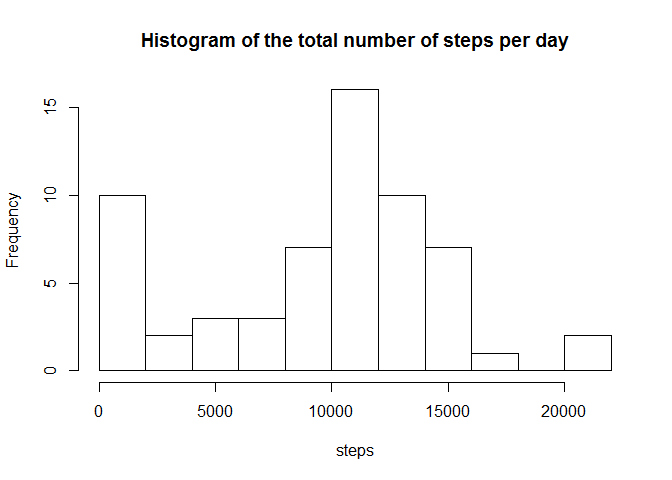

```r
hist(steps.perday, xlab="steps", breaks=10,
     main="Histogram of the total number of steps per day")
```

### 3. Calculate and report the mean and median of the total number of steps taken per day

```r
mean(steps.perday)
```

```
## [1] 9354.23
```

```r
median(steps.perday)
```

```
## [1] 10395
```

## What is the average daily activity pattern?

### 1. Make a time series plot of the 5-minute interval (x-axis) and the average number of steps taken, averaged across all days (y-axis)

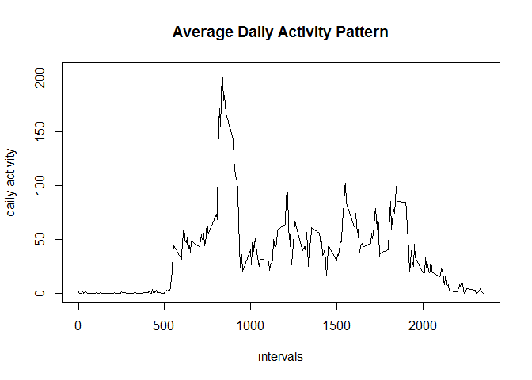

```r
daily.activity <- sapply(split(activity, activity$interval),
                         function(a) mean(a$steps,na.rm=T) )
plot(names(daily.activity), daily.activity, type="l",
     xlab="intervals", main="Average Daily Activity Pattern")
```

### 2. Which 5-minute interval, on average across all the days in the dataset, contains the maximum number of steps?

```r
names(sort(-daily.activity))[1]
```

```
## [1] "835"
```

The 5-minute interval which contains the maximum number of average steps is 8:35.

## Imputing missing values

### 1. Calculate and report the total number of missing values in the dataset (i.e. the total number of rows with NAs)

```r
good <- complete.cases(activity)
nrow(activity)-nrow( activity[good,] )
```

```
## [1] 2304
```

```r
sum(is.na(activity$steps))    # Double Check
```

```
## [1] 2304
```

The total number of missing values in the dataset is 2304.

### 2. Devise a strategy for filling in all of the missing values in the dataset. Here I use the median for each 5-min interval.

```r
imp <- sapply(split(activity, activity$interval), function(a) median(a$steps,na.rm=T) )
imp
```

```
##    0    5   10   15   20   25   30   35   40   45   50   55  100  105  110
##    0    0    0    0    0    0    0    0    0    0    0    0    0    0    0
##  115  120  125  130  135  140  145  150  155  200  205  210  215  220  225
##    0    0    0    0    0    0    0    0    0    0    0    0    0    0    0
##  230  235  240  245  250  255  300  305  310  315  320  325  330  335  340
##    0    0    0    0    0    0    0    0    0    0    0    0    0    0    0
##  345  350  355  400  405  410  415  420  425  430  435  440  445  450  455
##    0    0    0    0    0    0    0    0    0    0    0    0    0    0    0
##  500  505  510  515  520  525  530  535  540  545  550  555  600  605  610
##    0    0    0    0    0    0    0    0    0    0    0    0    0    0    0
##  615  620  625  630  635  640  645  650  655  700  705  710  715  720  725
##    0    0    0    0    0    0    0    8   13    7   13   14    0    0   12
##  730  735  740  745  750  755  800  805  810  815  820  825  830  835  840
##    0    0   15   19   19   28   41   25   32   13   45   33   37   19   51
##  845  850  855  900  905  910  915  920  925  930  935  940  945  950  955
```

[output cut: 25 more lines]

### 3. Create a new dataset that is equal to the original dataset but with the missing data filled in.

```r
activity.imp  <- activity
for (i in 1:nrow(activity.imp) )  {
      flag <- is.na(activity.imp$steps)
      activity.imp$steps[flag] <- imp[ as.character( activity.imp$interval[flag] ) ]
}
summary(activity.imp)
```

```
##      steps          date               interval
##  Min.   :  0   Min.   :2012-10-01   Min.   :   0.0
##  1st Qu.:  0   1st Qu.:2012-10-16   1st Qu.: 588.8
##  Median :  0   Median :2012-10-31   Median :1177.5
##  Mean   : 33   Mean   :2012-10-31   Mean   :1177.5
##  3rd Qu.:  8   3rd Qu.:2012-11-15   3rd Qu.:1766.2
##  Max.   :806   Max.   :2012-11-30   Max.   :2355.0
```

activity.imp is the new dataset with the missing data filled in.

### 4. Make a histogram of the total number of steps taken each day and Calculate and report the mean and median total number of steps taken per day. Do these values differ from the estimates from the first part of the assignment? What is the impact of imputing missing data on the estimates of the total daily number of steps?

```r
steps.perday.imp <- sapply(split(activity.imp, activity.imp$date),
                           function(a) sum(a$steps) )
mean(steps.perday.imp)
```

```
## [1] 9503.869
```

```r
median(steps.perday.imp)
```

```
## [1] 10395
```

```r
summary(steps.perday)
```

```
##    Min. 1st Qu.  Median    Mean 3rd Qu.    Max.
##       0    6778   10400    9354   12810   21190
```

```r
summary(steps.perday.imp)
```

```
##    Min. 1st Qu.  Median    Mean 3rd Qu.    Max.
##      41    6778   10400    9504   12810   21190
```

```r
steps.perday.imp[!steps.perday==steps.perday.imp]
```

```
## 2012-10-01 2012-10-08 2012-11-01 2012-11-04 2012-11-09 2012-11-10
##       1141       1141       1141       1141       1141       1141
## 2012-11-14 2012-11-30
##       1141       1141
```

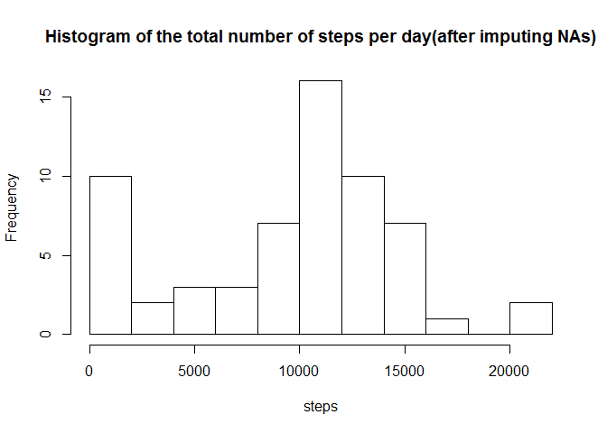

```r
hist(steps.perday.imp, xlab="steps", breaks=10,
     main="Histogram of the total number of steps per day(after imputing NAs)" )
```

The mean of the total number of steps per day is slightly greater than the orginal one, while the median remains the same. The histogram of total number of steps per day remains the same as the original one. Imputing missing data have only a tiny impact on the estimates of the total daily number of steps, since in the original dataset NA values resides in only 8 days, and imputed values(the median of the corresponding interval) are often relatively small, only influencing the lower tail of the distribution of total steps per day.

## Are there differences in activity patterns between weekdays and weekends?

### 1. Create a new factor variable in the dataset with two levels - “weekday” and “weekend” indicating whether a given date is a weekday or weekend day.

```r
wkd <- weekdays(activity.imp$date)
for (i in 1:length(wkd) )  {
      if (wkd[i]=="Sunday" | wkd[i]=="Saturday")   wkd[i] <- "weekend"
      else   wkd[i] <- "weekday"
}
activity.imp$wkd <- as.factor(wkd)
summary(activity.imp)
```

```
##      steps          date               interval           wkd
##  Min.   :  0   Min.   :2012-10-01   Min.   :   0.0   weekday:12960
##  1st Qu.:  0   1st Qu.:2012-10-16   1st Qu.: 588.8   weekend: 4608
##  Median :  0   Median :2012-10-31   Median :1177.5
##  Mean   : 33   Mean   :2012-10-31   Mean   :1177.5
##  3rd Qu.:  8   3rd Qu.:2012-11-15   3rd Qu.:1766.2
##  Max.   :806   Max.   :2012-11-30   Max.   :2355.0
```

Variable wkd indicates whether a given date is a weekday or weekend day.

### 2. Make a panel plot containing a time series plot (i.e. type = “l”) of the 5-minute interval (x-axis) and the average number of steps taken, averaged across all weekday days or weekend days (y-axis). See the README file in the GitHub repository to see an example of what this plot should look like using simulated data.

```r
activity.imp.wkday <- subset(activity.imp, activity.imp$wkd=="weekday")
activity.imp.wkend <- subset(activity.imp, activity.imp$wkd=="weekend")
summary(activity.imp.wkday)
```

```
##      steps             date               interval           wkd
##  Min.   :  0.00   Min.   :2012-10-01   Min.   :   0.0   weekday:12960
##  1st Qu.:  0.00   1st Qu.:2012-10-16   1st Qu.: 588.8   weekend:    0
##  Median :  0.00   Median :2012-10-31   Median :1177.5
##  Mean   : 31.15   Mean   :2012-10-31   Mean   :1177.5
##  3rd Qu.:  5.00   3rd Qu.:2012-11-15   3rd Qu.:1766.2
##  Max.   :806.00   Max.   :2012-11-30   Max.   :2355.0
```

```r
summary(activity.imp.wkend)
```

```
##      steps             date               interval           wkd
##  Min.   :  0.00   Min.   :2012-10-06   Min.   :   0.0   weekday:   0
##  1st Qu.:  0.00   1st Qu.:2012-10-18   1st Qu.: 588.8   weekend:4608
##  Median :  0.00   Median :2012-10-31   Median :1177.5
##  Mean   : 38.19   Mean   :2012-10-31   Mean   :1177.5
##  3rd Qu.: 17.25   3rd Qu.:2012-11-12   3rd Qu.:1766.2
##  Max.   :785.00   Max.   :2012-11-25   Max.   :2355.0
```

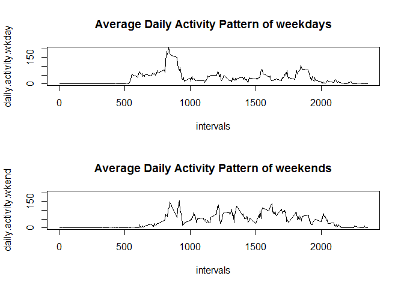

```r
daily.activity.wkday <- sapply(split(activity.imp.wkday, activity.imp.wkday$interval ),
                               function(a) mean(a$steps) )
daily.activity.wkend <- sapply(split(activity.imp.wkend, activity.imp.wkend$interval ),
                               function(a) mean(a$steps) )
par(mfrow = c(2, 1))
plot(names(daily.activity.wkday), daily.activity.wkday, type="l", ylim=c(0,200),
     xlab="intervals", main="Average Daily Activity Pattern of weekdays")
plot(names(daily.activity.wkend), daily.activity.wkend, type="l", ylim=c(0,200),
     xlab="intervals", main="Average Daily Activity Pattern of weekends")
```

Above is the panel plot made by Base Plotting System.

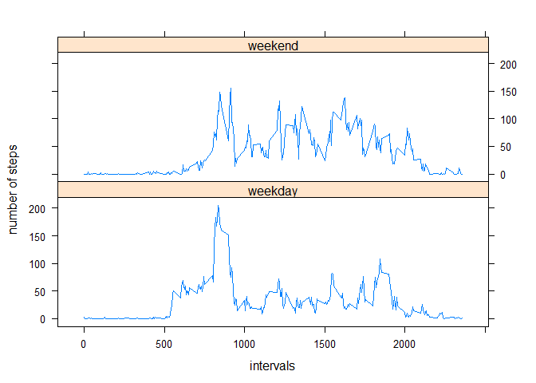

```r
daily.activity.imp <- c(daily.activity.wkday,daily.activity.wkend)
daily.activity.interval <- rep(unique(activity.imp$interval),2)
daily.activity.wkd  <- rep(c("weekday", "weekend"), each=length(daily.activity.wkday) )
library(lattice)
xyplot(daily.activity.imp~daily.activity.interval |daily.activity.wkd , type="l",
       layout = c(1, 2), xlab="intervals", ylab="number of steps")
```

Above is the panel plot made by Lattice Plotting System.